# Homework 1 Solutions

Jonathan M. Gilligan

2023-02-02

# Chapter 2: Exercises on Units, Energy, and Power

$\require{cancel}$

## Exercise 1

> A joule is an amount of energy, and a watt is a rate of using energy, defined as $1~\text{W} = 1~\text{J}/\text{s}$. How many joules of energy are required to run a 100 W light bulb for one day? Burning coal yields about $30 \times 10^{6}~\text{J}$ of energy per kg of coal burned. Assuming that the coal power plant is 30% efficient, how much coal has to be burned to light that light bulb for one day?

A 100 W light bulb burns 100 Joules per second. There are 3600 seconds in an hour and 24 hours in a day, so the light bulb will consume
$$\begin{aligned}
100~\text{Watt} \times 1~\text{day} &=
100~\frac{\text{Joule}}{\text{second}} \times 1~\text{day} \\
&= 100~\frac{\text{Joule}}{\text{second}} \times
1~\cancel{\text{day}}
\times \frac{24~\text{hours}}{\cancel{\text{day}}} \\
&= 100~\frac{\text{Joule}}{\text{second}} \times
24~\cancel{\text{hour}}
\times \frac{3600~\text{seconds}}{\cancel{\text{hour}}} \\
&= 100~\frac{\text{Joule}}{\cancel{\text{second}}} \times
86,400~
\cancel{\text{seconds}} \\
&= 8.64\times 10^{6}~
\text{Joules}
\end{aligned}$$

Now, figure out how much coal you have to burn to produce the energy.
$$\begin{aligned}
\text{coal burned} &= \frac{\text{Energy to power bulb}}{\text{Power
plant efficiency} \times \text{Joules}/\text{kg coal}} \\
&= \frac{8.64\times 10^{6}~
\text{Joules}}{0.3 \times
3.00\times 10^{7}~
\text{Joules}/\text{kg coal}} \\
&= \frac{8.64\times 10^{6}~
\cancel{\text{Joules}}}{
9.00\times 10^{6}~
\cancel{\text{Joules}}/\text{kg coal}} \\
&= 0.96~
\text{kg coal}
\end{aligned}$$

## Exercise 2

> This exercise asks you to calculate how many Joules of energy you can get for a dollar from different sources of energy.

### Part 2(a)

> 1. A gallon of gasoline carries with it about $1.3 \times 10^{8}$ J of energy. Given a price of $3 per gallon, how many Joules can you get for a dollar?

### Part 2(b)

> 2. Electricity goes for about $0.05 per kilowatt hour. A kilowatt hour is just a weird way to write Joules because a watt is a Joule per second, and a kilowatt hour is the number of Joules one would get from running 1000 W for one hour (3,600 seconds). How many Joules of electricity can you get for a dollar?

A kilowatt hour is the energy from using 1000 Watts for 1 hour, or 3,600 seconds. A Watt is 1 Joule per second, so 1 kWh = 1000 Watts × 3600 seconds.

**Answer:** $0.05 buys you a kilowatt hour of electricity, and a kilowatt hour of electricity has

$$\begin{aligned}
1~\text{kilowatt}~\text{hour} &=
1~\cancel{\text{kilowatt}}~\text{hour} \times
1,000~\frac{\text{Watts}}{\cancel{\text{kilowatt}}} \\
&= 1,000~\text{Watt}~\text{hours} \\
&= 1,000~\text{Watt}~\cancel{\text{hours}} \times
\frac{3,600~\text{seconds}}{\cancel{\text{hour}}} \\
&= 3.60\times 10^{6}~
\text{Watt}~\text{seconds} \\
&= 3.60\times 10^{6}~
\cancel{\text{Watt}}~\text{seconds} \times
1~\frac{\text{Joule}/\text{second}}{\cancel{\text{Watt}}} \\
&= 3.60\times 10^{6}~
\cancel{\text{seconds}} \times
1~\frac{\text{Joule}}{\cancel{\text{second}}} \\
&= 3.60\times 10^{6}~
\text{Joules}\\
\end{aligned}$$
so you get

$$\frac{1~\text{kWh}}{0.05~\text{dollars}}
\times
3.60\times 10^{6}~
\frac{\text{Joules}}{\text{kWh}} =
7.20\times 10^{7}~
\frac{\text{Joules}}{\text{dollar}}$$
from electricity. Written differently, that’s 72,000,000 Joules per dollar.

### Part 2(c)

> 3. A standard cubic foot of natural gas carries with it about 1.1 × 10<sup>6</sup> Joules of energy. You can get about 5 × 10<sup>5</sup> British Thermal Units (BTUs) of gas for a dollar, and there are about 1,030 BTUs in a standard cubic foot. How many Joules of energy in the form of natural gas can you get for a dollar?

**Answer:**

You can get 500,000 BTU per dollar from natural gas, and there are 1,030 BTU per scf (standard cubic foot), so you can get
$$500,000~
\cancel{\text{BTU}} \times \frac{1~\text{scf}}{
1,030~
\cancel{\text{BTU}}} =
485~
\text{scf}$$
for a dollar.

One scf of natural gas has 1.10×10<sup>6</sup> Joules of energy, so you can get
$$485~
\frac{\cancel{\text{scf}}}{\text{dollar}}
\times
1.10\times 10^{6}~
\frac{\text{Joules}}{\cancel{\text{scf}}} =
5.34\times 10^{8}~
\frac{\text{Joules}}{\text{dollar}}$$

### Part 2(d)

> 4. A ton of coal holds about 3.2 × 10<sup>10</sup> J of energy and costs about $40. How many Joules of energy in the form of coal can you get for a dollar?

**Answer:** One ton of coal has 3.20×10<sup>10</sup> Joules of energy, so you can get
$$\frac{1~\cancel{\text{ton coal}}}{40~\text{dollar}}
\times
3.20\times 10^{10}~
\frac{\text{Joules}}{\cancel{\text{ton coal}}} =
8.00\times 10^{8}~
\frac{\text{Joules}}{\text{dollar}}$$

### Part 2(e)

[output not shown]

> A dietary Calorie is about 4200 J. How many Joules of energy in the form of corn oil can you get for a dollar?

**Answer:** One ounce of oil has 240 Calories, and there are 4,200 Joules in a Calorie, so oil has
$$240~
\frac{\cancel{\text{Calories}}}{\text{ounce}}
\times
4,200~
\frac{\text{Joules}}{\cancel{\text{Calorie}}}
=
1.01\times 10^{6}~
\frac{\text{Joules}}{\text{ounce}}$$

One ounce of corn oil costs $0.10, so you get
$$\frac{1~\cancel{\text{ounce}}}
{0.10~
\text{dollars}} \times
1.01\times 10^{6}~
\frac{\text{Joules}}{\cancel{\text{ounce}}} =
1.01\times 10^{7}~
\frac{\text{Joules}}{\text{dollar}}$$

### Part 2(f)

> 6. Now we compare the different energy sources. Rank these five energy sources from cheap to expensive. What is the range of prices per Joule?

**Answer:**

- Coal = $1.25×10<sup>-9</sup> per joule
- Natural gas = $1.87×10<sup>-9</sup> per joule
- Electricity = $1.39×10<sup>-8</sup> per joule
- Gasoline = $2.31×10<sup>-8</sup> per joule
- Corn oil = $9.92×10<sup>-8</sup> per joule

## Exercise 4

> In this exercise, we compare the energy it took to produce the concrete in the Hoover Dam (outside Las Vegas) to the energy the dam produces from hydroelectric generation.

### Part 4(a)

> The Hoover Dam produces 2 × 10<sup>9</sup> W of electricity. It is composed of 7 × 10<sup>9</sup> kg of concrete. It requires 1 MJ of energy (1 megajoule, 1,000,000 Joules) to produce each kilogram of concrete. How much energy did it take to produce the concrete for the dam?

**Answer:** It took 7.0×10<sup>15</sup> Joules to produce the concrete for the Hoover dam.

### Part 4(b)

> How long is the payback time for the dam to generate as much energy in electricity as it took to produce the concrete?

**Answer:** The electric power the dam generates is measured in Watts, which are Joules per second. If we divide the energy to produce the concrete by the power the dam produces, the result will be the number of seconds for the dam’s electric generation to pay back the energy it took to produce the concrete.

$$\begin{aligned}
\text{Time to pay back energy} &=
\frac{\text{Energy to make concrete}}{\text{Power from dam}} \\
&= \frac{
7.00\times 10^{15}~
\text{Joules}}{
2.00\times 10^{9}~
\text{Watts}} \\
&= \frac{
7.00\times 10^{15}~
\cancel{\text{Joules}}}{
2.00\times 10^{9}~
\cancel{\text{Joules}}/\text{second}} \\
&= 3.50\times 10^{6}~
\text{seconds} \\
&= 3.50\times 10^{6}~
\cancel{\text{seconds}} \times
\frac{1~\cancel{\text{hour}}}{3,600~\cancel{\text{seconds}}} \times
\frac{1~\text{day}}{24~\cancel{\text{hours}}} \\
&= 40~
\text{days}
\end{aligned}$$

3,500,000 seconds, or 40 days, for the electricity generated by the Hoover dam to repay the energy it took to produce the concrete in the dam.

## Exercise 5

> It takes approximately 2.0 × 10<sup>9</sup> J of energy to manufacture 1 m<sup>2</sup> of crystalline-silicon photovoltaic cell. An average of 250 W/m<sup>2</sup> falls on the Earth. Assume that the solar cell is 18% efficient (that is, it converts 18% of the energy from sunlight into electricity). Calculate how long it would take for the solar cell to repay the energy it took to manufacture it.

**Answer:** It takes 4.4×10<sup>7</sup> seconds, or 510. days, or 1.4 years.

## Exercise 7

### Part 7(a)

> Infrared light has a wavelength of about 10 microns. What is its wavenumber in cm<sup>-1</sup>?

From page 11 in the textbook,

$$\begin{aligned}
n \left[ \frac{\text{cycles}}{\text{cm}} \right] &=
\frac{1}{
\lambda \left[ \frac{\text{cm}}{\text{cycle}} \right]
}
1~\text{cm} &= 10,000 \mu\text{m} \\
n &= \frac{1}{10~\mu\text{m}} \\
&= \frac{1}{10~\cancel{\mu\text{m}} \times \frac{1~\text{cm}}{10,000
\cancel{\mu\text{m}}}} \\
&= \frac{1}{\frac{1}{1000}~\text{cm}} \\
&= 1000~\text{cm}^{-1}
\end{aligned}$$

### Part 7(b)

> Visible light has a wavelength of about 0.5 microns. Whas is its frequency in Hz (cycles per second)?

From page 10 of the textbook,

$$\begin{aligned}
\lambda \left[ \frac{\text{cm}}{\text{cycle}} \right] &=
\frac{c \left[ \frac{\text{cm}}{\text{second}} \right]}{
\nu \left[ \frac{\text{cycles}}{\text{second}} \right]}
\end{aligned}$$

We can rearrange this equation to give $\nu$ as a function of $\lambda$:

$$\begin{aligned}
\nu \left[ \frac{\text{cycles}}{\text{second}} \right] &=
\frac{c \left[ \frac{\text{cm}}{\text{second}} \right]}{
\lambda \left[ \frac{\text{cm}}{\text{cycle}} \right]
} \\
c &= 3\times10^{10}~\text{cm}/\text{second} \\
\nu &= \frac{3\times10^{10}~\text{cm}/\text{second}}{
0.5~\cancel{\mu\text{m}} \times
\frac{1~\text{cm}}{10,000~\cancel{\mu\text{m}}}} \\
&= \frac{3\times10^{10}~\cancel{\text{cm}}/\text{second}}{
5\times 10^{-5}~\cancel{\text{cm}}} \\
&= 6.00\times 10^{14}~
\left[ \frac{\text{cycles}}{\text{second}}\right]
\end{aligned}$$

### Part 7(c)

> FM radio operates at a frequency of about 100 MHz. What is its wavelength?

Again, we use the equation from page 10, noting that 1 MHz is one million cycles per second:
$$\begin{aligned}
\lambda \left[ \frac{\text{cm}}{\text{cycle}} \right] &=
\frac{c \left[ \frac{\text{cm}}{\text{second}} \right]}{
\nu \left[ \frac{\text{cycles}}{\text{second}} \right]} \\
&= \frac{3\times10^{10} \text{cm}/\cancel{\text{second}}}{100 \times
10^6~\left[\frac{\text{cycles}}{\cancel{\text{second}}} \right]} \\
&= 300~\text{cm}
\end{aligned}$$
# Chapter 3: Layer Models

For these exercises, use the following numbers:

- I<sub>solar</sub> = 1350 W/m<sup>2</sup>
- $\sigma = 5.67 \times 10^{-8}$
- $\alpha = 0.30$
- $\varepsilon = 1.0$

## Exercise 2

> **A Two-Layer Model.** Insert another atmospheric layer into the model, just like the first one. The layer is transparent to visible light but a blackbody for infrared.

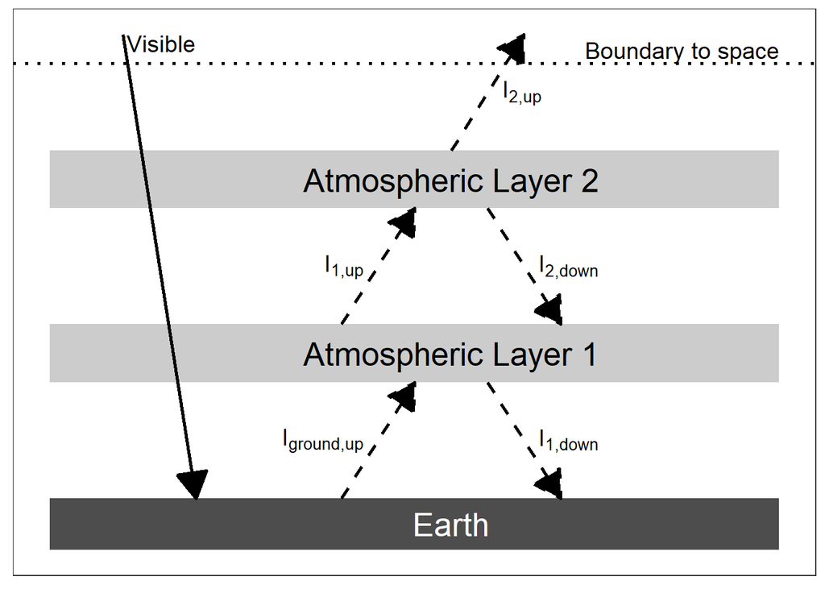

An energy diagram for a planet with two panes of glass for an atmosphere. The intensity of absorbed visible light is $(1 - \alpha) I_{solar} / 4$.

> 1. Write the energy budgets for both atmospheric layers, for the ground, and for the Earth as a whole, like we did for the One-Layer Model.

**Answer:**

At each layer, calculate the heat in (in the diagram, this is the sum of all the intensities with arrows that end at the atmospheric layer) and the heat out (the sum of all the intensities that start at the atmospheric layer and have arrows pointing away from it).

- Top of the atmosphere: $I_{2,\text{up}} = I_{\text{visible}} = (1 - \alpha) I_{\text{solar}} / 4$
- Layer 2: $I_{1,\text{up}} = I_{2,\text{up}} + I_{2,\text{down}}$
- Layer 1: $I_{\text{ground,up}} + I_{2,\text{down}} = I_{1,\text{up}} + I_{1,\text{down}}$
- Ground: $I_{\text{ground,up}} = I_{\text{visible}} + I_{1,\text{down}}$
> 2. Manipulate the budget for the Earth as a whole to obtain the temperature T<sub>2</sub> of the top atmospheric layer, labeled Atmospheric Layer 2 in the figure above. Does this part of the exercise seem familiar in any way? Does the term ring any bells?

Top of the atmosphere:

$$\begin{aligned}
I_{2,\text{up}} &= I_{\text{visible}} = \frac{(1 - \alpha)
I_{\text{solar}}}{4}\\
I_{2,\text{up}} &= \varepsilon \sigma T_2^4\\
T_2 &= \sqrt[4]{\frac{I_{2,\text{up}}}{\varepsilon \sigma}} \\
&= \sqrt[4]{\frac{(1 - \alpha) I_{\text{solar}}}{4 \varepsilon
\sigma}} \\
&= T_{\text{bare rock}}
\end{aligned}$$

This is the same as the bare-rock temperature.

**Answer:** The temperature of layer 2 is 254. K, which is the same as the bare-rock temperature. In layer models, the top layer of the atmosphere is *always* the bare-rock temperature.

> 3. Insert the value you found for T<sub>2</sub> into the energy budget for layer 2, and solve for the temperature of layer 1 in terms of layer 2. How much bigger is T<sub>1</sub> than T<sub>2</sub>?

From the energy budget for Layer 2, I<sub>1,up</sub> = I<sub>2,up</sub> + I<sub>2,down</sub>. The temperature of the bottom of the layer is the same as the temperature for the top of the layer, so I<sub>2,down</sub> = I<sub>2,up</sub>

$$\begin{aligned}
I_{\text{2,down}} &= I_{\text{2,up}} \\
I_{\text{1,up}} &= I_{\text{2,up}} + I_{\text{2,down}} \\
&= 2 I_{\text{2,up}} \\
T_1 &= \sqrt[4]{\frac{I_{\text{1,up}}}{\epsilon \sigma}} \\
&= \sqrt[4]{\frac{2 I_{\text{2,up}}}{\epsilon \sigma}} \\
&= \sqrt[4]{2} T_2 \\
&= \sqrt[4]{2}\; T_{\text{bare rock}} \\
\end{aligned}$$

**Answer:** The temperature of layer 1 is 302. K. This is the same as the ground temperature in a 1-layer model.

> 4. Now insert the value you found for T<sub>1</sub> into the budget for atmospheric layer 1 to obtain the temperature of the ground, T<sub>ground</sub>. Is the greenhouse effect stronger or weaker because of the second layer?

From the energy budget for layer 1,

$$\begin{aligned}
I_{\text{ground,up}} + I_{\text{2,down}} &= I_{\text{1,up}} +
I_{\text{1,down}} \\
I_{\text{ground,up}} &= I_{\text{1,up}} + I_{\text{1,down}} -
I_{\text{2,down}} \\
\text{we} &\text{ know that} \\
I_{\text{1,down}} &= I_{\text{1,up}} \\
&\text{and} \\
I_{\text{2,down}} &= I_{\text{2,up}} \\
&\text{so} \\
I_{\text{ground,up}} &= 2 I_{\text{1,up}} - I_{\text{2,up}} \\
\text{we} &\text{ also know that} \\
I_{\text{1,up}} &= 2 I_{\text{2,up}} \\
&\text{so} \\
I_{\text{ground,up}} &= 4 I_{\text{2,up}} - I_{\text{2,up}} \\
&= 3 I_{\text{2,up}}
\end{aligned}$$

$$\begin{aligned}
T_{\text{ground}} &=
\sqrt[4]{\frac{I_{\text{ground,up}}}{\varepsilon \sigma}} \\
&= \sqrt[4]{\frac{3 I_{\text{2,up}}}{\varepsilon \sigma}} \\
&= \sqrt[4]{3}\; T_2 \\
&= \sqrt[4]{3}\; T_{\text{bare rock}}
\end{aligned}$$

In a 1-layer model, the ground temperature was $\sqrt[4]{2}$ times the bare-rock temperature, and in a 2-layer model, the ground temperature is $\sqrt[4]{3}$ times the bare-rock temperature.

## Exercise 3.3

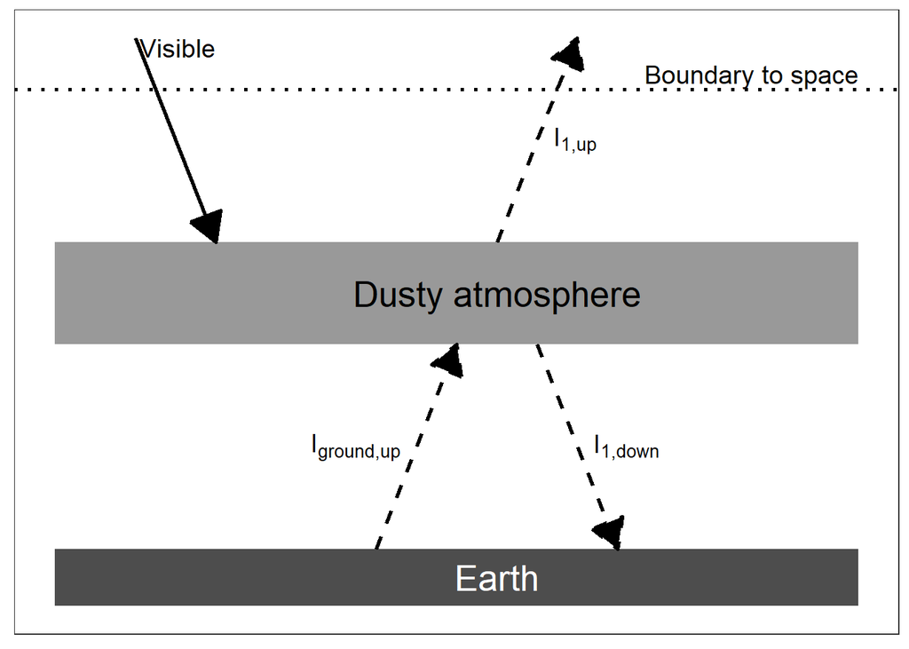

An energy diagram for a planet with an opaque pane of glass for an atmosphere. The intensity of absorbed visible light is $(1 - \alpha) I_{solar} / 4$.

> **Nuclear Winter.** Let us go back to the One-Layer Model but change it so that the atmospheric layer absorbs visible light rather than allowing it to pass through (See the figure above). This could happen if the upper atmosphere were filled with dust. For simplicity, assume that the albedo of the Earth remains the same, even though in the real world it might change with a dusty atmosphere.> What is the temperature of the ground in this case?

**Answer:** Here, the key difference is that the heat from the sun is absorbed by the atmosphere instead of passing through the atmosphere to the ground.

The equation for the atmosphere is the same as in the 1-layer model because we use the energy balance at the boundary to space:

$$I_{\text{atm, up}} = I_{\text{visible}}
= \frac{(1 - \alpha) I_{\text{solar}}}{4}$$

and the temperature of the atmosphere is the bare-rock temperature, just as the top layer of the atmosphere is for every layer model.

However, things are different at the ground. The energy balance at the dusty atmosphere is

$$\begin{aligned}
I_{\text{visible}} + I_{\text{ground,up}} &= I_{\text{atm,up}} +
I_{\text{atm,down}} \\
I_{\text{ground,up}} &= I_{\text{atm,up}} + I_{\text{atm,down}} -
I_{\text{visible}} \\
& \text{But} \\
I_{\text{atm,up}} &= I_{\text{atm,down}} = I_{\text{visible}}. \\
& \text{So} \\
I_{\text{ground,up}} &= I_{\text{atm,up}}. \\
\text{This} & \text{ means that} \\
T_{\text{ground}} &= T_{\text{atmosphere}} = T_{\text{bare-rock}}
\end{aligned}$$

T_ground = 254. K. This is the same as the bare-rock temperature.

The effect of the dust in the atmosphere is to cancel out the greenhouse effect and cool off the surface to the bare-rock temperature. The greenhouse effect works because the atmosphere is transparent to shortwave light and opaque to longwave light. If the atmosphere becomes opaque to shortwave light, then the greenhouse effect doesn’t work.